# Reproducability Assignment

2023-11-11

*The following is a template .rmd RMarkdown file for you to use for your homework submission.*

*Please Knit your .rmd to a PDF format or HTML and submit that with no identifiers like your name.*

*To create a PDF, first install tinytex and load the package. Then press the Knit arrow and select “Knit to PDF”.*

## QUESTION 01: Data Visualisation for Science Communication

*Create a figure using the Palmer Penguin dataset that is correct but badly communicates the data. **Do not make a boxplot**.*

*Use the following references to guide you:*

- [*https://www.nature.com/articles/533452a*](https://www.nature.com/articles/533452a)
- [*https://elifesciences.org/articles/16800*](https://elifesciences.org/articles/16800)

*Note: Focus on visual elements rather than writing misleading text on it.*

### a) Provide your figure here:

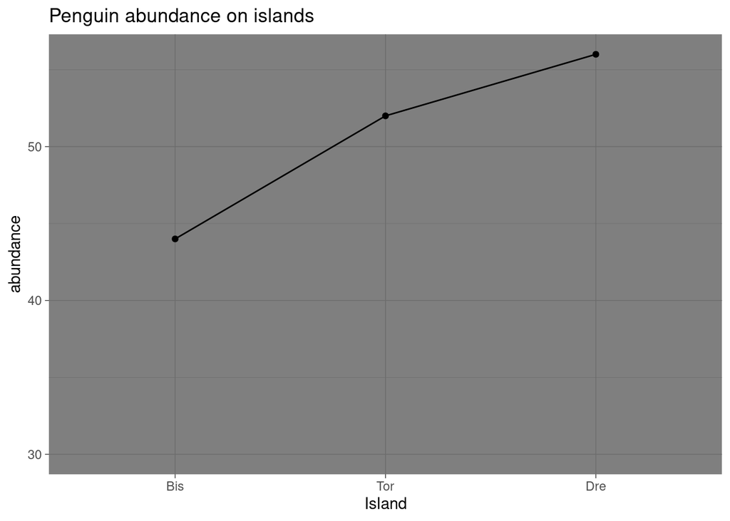

### b) Write about how your design choices mislead the reader about the underlying data (200-300 words).

A surprisingly common graphical miscommunication in academic literature is connecting discrete data points with a continuous line. So I have used this design floor here to show how it can be misleading. The connecting line suggests that there are values between the point plotted that do (or on average will) fall on the line (Franzblau & Chung 2012). Often times these ‘between values’ can just not be known (eg if a survey questions discrete age groups of 20-30, and 30-40). In our case, this is more extreme as there is no ‘between value’ possible between these categories as they are not related, like age is. That is, there is no clear connection between these 3 islands that would suggest a connection as our misleading line does (Durbin 2004). This data IS useful because it could give us information to help conservation or ecotourism on the most populous islands, or even just show biases in the data set. However, using a connected line graph suggests that there is a trend, such as “penguin abundance is increasing”, even though we know that this data shows nothing of the sort.

It actually obscures a lot of information too. In general, it is bad practice to plot summary statistics (such as mean) without any way to see the raw data (Franzblau & Chung 2012). In this case it is not clear that the Biscoe island is dominated by Gentoo penguins, and Dream island by Chinstrap. This means that, on a fundamental level, the means are not very useful to compare. Showing the underlying data would allow us to colour by species (or other confounding variables) so we can see biases like these and remove them from the data - and, for example, compare just the abundance of Adelie on each island

##References

Franzblau, L. E. & Chung, K. C. (2012) Graphs, Tables, and Figures in Scientific Publications: The Good, the Bad, and How Not to Be the Latter. The Journal of hand surgery (American ed.). [Online] 37 (3), 591–596.

Durbin, C. G. (2004) Effective Use of Tables and Figures in Abstracts, Presentations, and Papers. Respiratory Care Oct 2004, 49 (10) 1233-1237;

## QUESTION 2: Data Pipeline

*Write a data analysis pipeline in your .rmd RMarkdown file. You should be aiming to write a clear explanation of the steps as well as clear code.*

*Your code should include the steps practiced in the lab session:*

- *Load the data*
- *Appropriately clean the data*
- *Create an Exploratory Figure (**not a boxplot**)*
- *Save the figure*
- **New**: Run a statistical test
- **New**: Create a Results Figure
- *Save the figure*

*An exploratory figure shows raw data, such as the distribution of the data. A results figure demonstrates the stats method chosen, and includes the results of the stats test.*

*Between your code, communicate clearly what you are doing and why.*

*Your text should include:*

- *Introduction*
- *Hypothesis*
- *Stats Method*
- *Results*
- *Discussion*
- *Conclusion*

*You will be marked on the following:*

### a) Your code for readability and functionality

### b) Your figures for communication

### c) Your text communication of your analysis

*Below is a template you can use.*

# Question 2 Answer

### Introduction

The Palmer Penguins data set includes physiological variables of 3 of the major penguin species, such as body mass. Due to the large body of literature studying the behaviour of these charismatic animals, this maybe an opportunity to study sexual selection in relation to these morphological characteristics. Sexual dimorphism in body mass is common in birds, though not as pronounced as other taxa like insects. The direction of size dimorphism can swing for larger males or females depending on the taxa (Schoenjahn et al 2020). This study aims to find evidence of sexual dimorphism in the Gentoo species, the direction, and use literature analysis to propose scenarios for the ultimate evolutionary explanation at play - namely if it is inter or intrsexual selection.

This Code is used to interrogate the question of if Gentoo penguins have significantly different body mass between sexes. It will use a data set of 3 penguin species, “palmerpenguins” (Horst, Hill, Gorman 2020). As a result, we will show code to manipulate the data for the Gentoo penguins, test the difference with a t-test, and then visualise that test with a figure.

**Use this Code to install the packages you require:**

```r
#Install and library the necessary packages
install.packages(c("ggplot2", "palmerpenguins", "janitor", "dplyr", "car", "ragg", "Hmisc", "rstatix", "ggpubr"))
```

**Then use This code to Library the Packages as needed:**

```r
library(ggplot2)
library(palmerpenguins)
library(janitor)
library(dplyr)
library(car)
library(ragg)
library(Hmisc)
library(rstatix)
library(ggpubr)
```

**Use this Code to clean (making data computer readable and lacking NAs) and prepare (filtering out the focul species) the Gentoo data:**

```r
#Save the raw data as a csv file into the data folder
write.csv(penguins_raw, "data/penguins_raw.csv")

#Also load the function definition scripts, both cleaning and plotting.
source('functions/Functions_cleaning.R')
source('functions/Functions_plot.R')

#To clean the raw data, run the pipeline and refer to the functions script for better understanding
Penguins_cleaned <- penguins_raw %>%
  clean_column_names() %>% #function to make col names computer readable
  shorten_species() %>% #function to shorten species name to layman's name
  Remove_NAsex() #function to remove individuals with NA sex

#Check that cleaning was successful
head(Penguins_cleaned)
```

```
## # A tibble: 6 × 17
##   study_name sample_number species region island    stage          individual_id
##   <chr>              <dbl> <chr>   <chr>  <chr>     <chr>          <chr>
## 1 PAL0708                1 Adelie  Anvers Torgersen Adult, 1 Egg … N1A1
## 2 PAL0708                2 Adelie  Anvers Torgersen Adult, 1 Egg … N1A2
## 3 PAL0708                3 Adelie  Anvers Torgersen Adult, 1 Egg … N2A1
## 4 PAL0708                5 Adelie  Anvers Torgersen Adult, 1 Egg … N3A1
## 5 PAL0708                6 Adelie  Anvers Torgersen Adult, 1 Egg … N3A2
## 6 PAL0708                7 Adelie  Anvers Torgersen Adult, 1 Egg … N4A1
## # ℹ 10 more variables: clutch_completion <chr>, date_egg <date>,
## #   culmen_length_mm <dbl>, culmen_depth_mm <dbl>, flipper_length_mm <dbl>,
## #   body_mass_g <dbl>, sex <chr>, delta_15_n_o_oo <dbl>, delta_13_c_o_oo <dbl>,
## #   comments <chr>
```

```r
#function to subset the data to remove two other species to only the selected species, then remove other data from the frame with 'select' in the pipe.
Gentoo_only <- filter_SelectedSpecies_only(Penguins_cleaned, 'Gentoo') %>%
  select(sex, body_mass_g)

#Check the cleaned data has been correctly filtered
head(Gentoo_only)
```

```
## # A tibble: 6 × 2
##   sex    body_mass_g
##   <chr>        <dbl>
## 1 FEMALE        4500
## 2 MALE          5700
## 3 FEMALE        4450
## 4 MALE          5700
## 5 MALE          5400
## 6 FEMALE        4550
```

```r
# and save to your data file
write.csv(Gentoo_only, "data/Gentoo_only.csv")
```

**Use this code to interrogate the Gentoo size sexual dimorphism, via an exploratory histogram:**

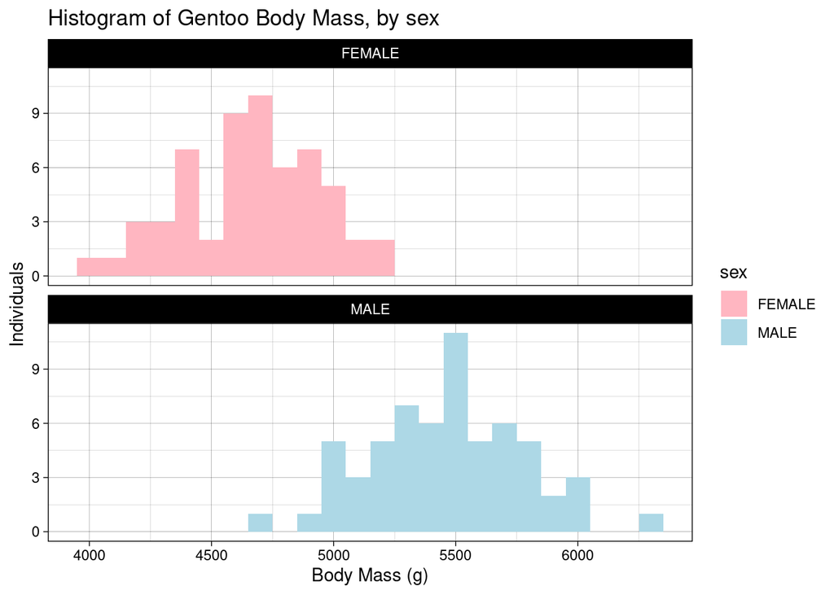

```r
# Visualize the body mass of sexes with a histogram, faceted by sex (to see coding of this figure, look at the functions r script).
Figure1 <- plot_histogram(data = Gentoo_only,
                          x = "body_mass_g", facet_by = "sex",
                          title_as ="Histogram of Gentoo Body Mass, by sex",
                          x_axis_lab= "Body Mass (g)", y_axis_lab= "Individuals") %>%
  print()
```

```r
# Save this figure using the save figure function, which allows you to specify dimensions (width, height, resolution, and scale), the units of width and height are 'cm'.
save_figure(Figure1, "figures/Figure1_Histogram.png", 40, 30, 170, 3)
```

### Hypothesis

From the exploratory figures, we hypothesis that male Gentoo penguins have a larger body mass than female Gentoos. So for statistical analysis to answer this question using our sample set, we can set the hypotheses that:

Ho: There is no difference in average body mass between male and female Gentoos. Ha: There is a difference in average body mass between male and female Gentoos.(2-tailed)

### Statistical Methods

We can test this using an independent 2 sample t-test because the 2 sample we are comparing were not paired on collection (provided that the sample meets the assumptions). We can see that the assumption of normality in both samples is met in the histogram. The assumption of equal variance can be tested with a levenes Test. This returns a significant p value (p<0.05) when the variance of the two samples are significantly different from each other, so in this case an insignificant value means we do meet the assumptions.

**Use this code to conduct the statistical analysis:**

```r
# Perform an independent two sample t-test to see the difference between the mean body mass of sexes, and its significance
# First check that the histograms meet the assumption of normality by observing the prior histograms (which they do)

# to check the assumption of similar variance, we use the levene test. It returns a P value of 0.4, meaning the variances can be considered equivalent.
leveneTest(data = Gentoo_only, body_mass_g ~ sex, centre = mean)
```

```
## Levene's Test for Homogeneity of Variance (center = median: mean)
##        Df F value Pr(>F)
## group   1  0.5754 0.4497
##       117
```

```r
# Next use the 2 sample t test function. It returns an effect size of males having an average body mass 805g larger, which is significant (p-value < 2.2e-16)
t.test(data = Gentoo_only, body_mass_g ~ sex, var.equal = TRUE)
```

```
##
##  Two Sample t-test
##
## data:  body_mass_g by sex
## t = -14.722, df = 117, p-value < 2.2e-16
## alternative hypothesis: true difference in means between group FEMALE and group MALE is not equal to 0
## 95 percent confidence interval:
##  -913.4008 -696.7886
## sample estimates:
## mean in group FEMALE   mean in group MALE
##             4679.741             5484.836
```

### Results & Discussion

From the histogram and levene’s test we can see that our data meets the assumptions so is valid for independent t-testing. It returned a significant difference in body mass (t = -14.722, df = 117, p-value < 2.2e-16) allowing us to reject our Null hypothesis and accept the alternative that Gentoo’s have different body mass between the sexes. The effect size was males being around 800g larger, on mean average. This effect size, along with the 95% confidence intervals and raw data is presented in figure 2, to aid with interpretation of the statistical test. The significant difference thus allows us to say that the population also shows this trend. This may suggest that male Gentoos take part in competition for mate selection with large size giving advantage, as this correlation has been noted in other birds (Fairbairn et al 2007). However, in the literature, studies of Gentoo mating behavior seem to show that they spend the most time resting, while conducting self maintenance, low level vigilance, and courtship rituals like pebble collecting. This suggests that mate competition may not be the direct explanation, though the fact that males caught fish during the egg laying period (spending much more time in the water) may explain why they need more muscle and fat reserves (Davis & Darby 1990).

**Use this code to plot and save the explanatory figures:**

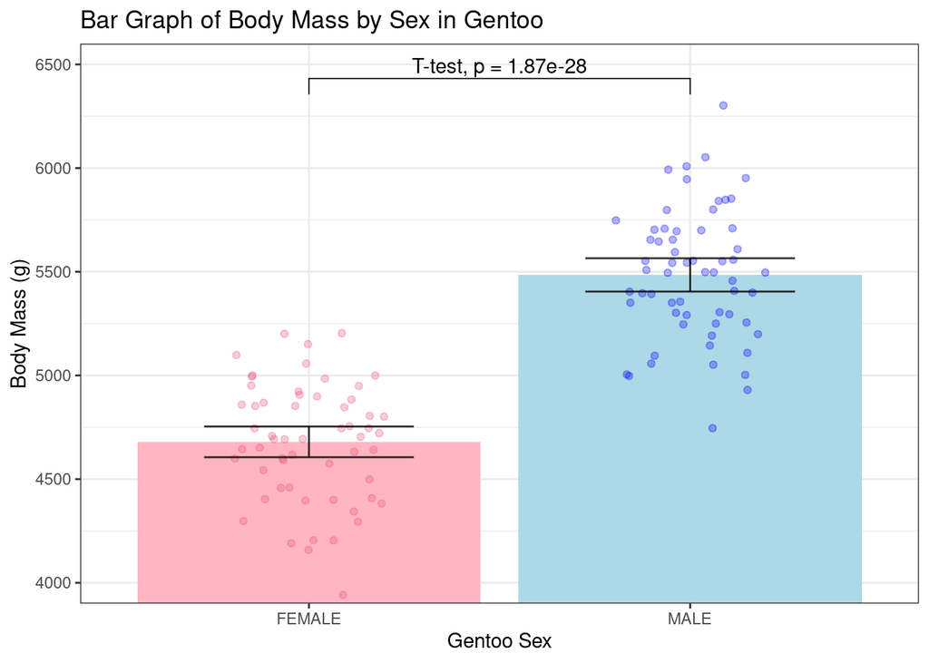

```r
# This function will plot the body mass of the two sexes as a bar graph, including the actual data points with geom_jitter, 95% confidence intervals, and anotation with the statistical test (a t test performed within the function)

Figure2 <- plot_bar_BodyMass_Sex(data = Gentoo_only) %>%
  print()
```

```r
# Save this figure as a png file in a file called "figures", using the same function as before (the width and height are specified in cm)
save_figure(Figure2, "figures/Figure2_Bar.png", 30, 40, 175, 2.5)

# To save a graph that is more suitable for a poster or power point presentation we can specify increased size of important elements with scale
save_figure(Figure2, "figures/Figure2_Bar_Presentation.png", 30, 30, 175, 2.8)
```

**Use this code to display any values that may be needed for transparency, such as the Means, SE and CI.**

```r
# If you want to see the statistics behind this graph, use the calculate_stats function. Specify the Sex, the function will isolate this sex and retrieve the useful statistics.
Male_stats <- calculate_stats(Gentoo_only, 'MALE')
```

```
## # A tibble: 1 × 3
##    mean    SE    CI
##   <dbl> <dbl> <dbl>
## 1 5485.  40.1  80.2
```

```r
Female_stats <- calculate_stats(Gentoo_only, 'FEMALE')
```

```
## # A tibble: 1 × 3
##    mean    SE    CI
##   <dbl> <dbl> <dbl>
## 1 4680.  37.0  73.9
```

```r
#And then we can group them into a data frame so that we can print it and view them all together easily.
statistics_frame <- data_frame(
  Sex = c('Female', 'Male'),
  Mean = c(Male_stats$mean, Female_stats$mean),
  SE = c(Male_stats$SE, Female_stats$SE),
  CI = c(Male_stats$CI, Female_stats$CI)
) %>%
  print()
```

[output not shown]

### Conclusion

Male Gentoo penguins are on average larger than females, by around 800g on average (figure 2). This is a significant difference (t = -14.722, df = 117, p-value < 2.2e-16), which we can see in Figure 2 (showing 95% CI). This sexual dimorphism suggests that selection pressures are asymmetric between the sexes. The most common explanation for this, including within birds, is mate competition and intrasexual selection on the competing males. Although, there are alternative explanations, such as an advantage in hunting and avoiding predators during the mating period. This aligns with behavioral observations and may indicate that females are choosing males with larger body mass as they will likely be better at provisioning them during the laying season. In this case, what may initially seem like a textbook example of intrasexual selection between competing males, may in fact be intersexual selection of female mate choice. This study is observational so cannot directly discern causality from the correlation, but suggests a route to further investigate the sexual selection at play.

#### Citations

The R version and package info can be found it “Session_info.txt”

Davis, L. S. & Darby, J. T. (1990) Penguin biology. London: Academic Press.

Fairbairn, D. J. et al. (2007) Sex, Size and Gender Roles: Evolutionary Studies of Sexual Size Dimorphism. [Online]. Oxford: Oxford University Press.

Jonny Schoenjahn, Chris R Pavey, Gimme H Walter, Why female birds of prey are larger than males, Biological Journal of the Linnean Society, Volume 129, Issue 3, March 2020, Pages 532–542.

Analysis was conducted using R (R Core Team, 2022), RStudio (Posit team, 2023, Integrated Development Environment for R. Posit Software, PBC, Boston, MA. URL http://www.posit.co/), and the packages:

- H. Wickham. ggplot2: Elegant Graphics for Data Analysis. Springer-Verlag New York, 2016
- Firke S (2023). *janitor: Simple Tools for Examining and Cleaning Dirty Data*. R package version 2.2.0, https://CRAN.R-project.org/package=janitor.
- Wickham H, François R, Henry L, Müller K, Vaughan D (2023). *dplyr: A Grammar of Data Manipulation*. R package version 1.1.3, https://CRAN.R-project.org/package=dplyr.
- Fox J, Weisberg S (2019). *An R Companion to Applied Regression*, Third edition. Sage, Thousand Oaks CA. https://socialsciences.mcmaster.ca/jfox/Books/Companion/.
- Pedersen T, Shemanarev M (2023). *ragg: Graphic Devices Based on AGG*. R package version 1.2.6, https://CRAN.R-project.org/package=ragg.
- Harrell Jr F (2023). *Hmisc: Harrell Miscellaneous*. R package version 5.1-1, https://CRAN.R-project.org/package=Hmisc.
- Kassambara A (2023). *rstatix: Pipe-Friendly Framework for Basic Statistical Tests*. R package version 0.7.2, https://rpkgs.datanovia.com/rstatix/. -Kassambara A (2023). *ggpubr: ‘ggplot2’ Based Publication Ready Plots*. R package version 0.6.0, https://rpkgs.datanovia.com/ggpubr/.

And with the data set: - Horst AM, Hill AP, Gorman KB (2020). palmerpenguins: Palmer Archipelago (Antarctica) penguin data. R package version 0.1.0. https://allisonhorst.github.io/palmerpenguins/. doi: 10.5281/zenodo.3960218.

## QUESTION 3: Open Science

### a) GitHub

*Upload your RProject you created for **Question 2** and any files and subfolders used to GitHub. Do not include any identifiers such as your name. Make sure your GitHub repo is public.*

*GitHub link:* https://github.com/userSGK4/Reproduce-Assignment

*You will be marked on your repo organisation and readability.*

### b) Share your repo with a partner, download, and try to run their data pipeline.

*Partner’s GitHub link:* https://github.com/user39201/assignment_palmer_penguins

*You **must** provide this so I can verify there is no plagiarism between you and your partner.*

### c) Reflect on your experience running their code. (300-500 words)

- *What elements of your partner’s code helped you to understand their data pipeline?*

They had very thorough explanations of the code, what they aimed to do in each chunk. They introduced each novel function clearly; explaining the objective ans sometimes justifying choices (such as why they used pdf over other image saving formats). They also make it clear when they are calling on certain folders and where data is being saved to, which makes it easier to follow the overall flow. They used functions where appropriate which condensed the code, used clear and computer readable object names, and cited all packages used.

- *Did it run? Did you need to fix anything?*

It ran perfectly and I did not need to fix anything.

- *What suggestions would you make for improving their code to make it more understandable or reproducible, and why?*

They decided to explain the code outside the chunks, rather than using # to follow the code as it is used. This meant I was often flicking back and fourth to try and understand what the explanation was refering to, or to find the explanation for the part of the code I was running. This may be a preference, as I know my partner usually runs their code as full chunks, wheras I like to run line by line. Though, I do believe explaining the data in chunks, rather than as you go on, makes it harder to follow. Secondly I would have prefered if they used head() or similar funcitons to show what changes happened to the data in the cleaning section, rather than just trusting that the code worked. Allowing the reproducer to see what changed when they call “subset_columns” along witht he explanation would aid followability.

- *If you needed to alter your partner’s figure using their code, do you think that would be easy or difficult, and why?*

They have included clear function files where I can edit the functions that produce figures directly. Here they have used # to anotate some of the parts of the function. Though some are without explanation, such as the “strip.text” in the exploratory function, which could make this more difficult. But most cases are very well anotated. In terms of altering the figure dimentions, resolution and scaling upon saving; they do not show in the main script that you can specify these values. I can go into the function script and alter these values within the function easily, though it may be slighttly more accesible if width, height, resolution, and scaling were variables in the function which I could easily alter in the main script, without having to change the core function coding.

### d) Reflect on your own code based on your experience with your partner’s code and their review of yours. (300-500 words)

- *What improvements did they suggest, and do you agree?*

One suggestion was to not use uppercase in object and variable names. One of our coding professors did mention this, though another said that you could use uppercase this way. When googling, it seems that people may not like it because it makes coding faster, and others that it may stop errors down the line. Whether this is a large issue may depend on context.

They said that I should have written CSV files for the cleaned data as well as the data I used (Gentoo_only), whereas I chose to only write one for the cleaned *and* filtered data. I think this is not too bad, because I made a point of using head() to follow how the data was changing, and do not think that an extra csv file would significantly increase follow ability (as the head function sort of attempts to do this already).

Although my saved figures do allow you to change resolution, they are right that a vector or pdf is easier to use and more widely accessible.

- *What did you learn about writing code for other people?*

I found that errors in spelling are easy to make, which makes reproducibility important, especially for me as I have strong dyslexia. So I am lucky they only found one. I also found that people code in different styles; me and my partner had to conform to how we write code (as I write line by line, wheres he thinks in chunks). This illustrates how, even with different preferences, you can still have reproducibility. I found that it is actually quite easy to annotate code if you do it as you go along. And I also found that the use of clear folder, function scripts, and Git all made my life easier; showing that reproducible work also means it is clear, concise, and navigable *for me* when something goes wrong!